# MySQL in Python

MySQL merupakan software yang digunakan untuk bahasa pemrogaman SQL yang digunakan pada relational database. MySQL juga bisa dihubungkan ke bahasa pemrograman lainnya yaitu Python

Untuk menghubungkannya terlebih dahulu perlu untuk menginstall mysql.connector pada anaconda prompt, lalu menghubungkannya lewat cara di bawah ini

```python
import mysql.connector

mydb = mysql.connector.connect(
    host='localhost', #host
    user='root', #user
    password='abcdef', #password
    database='example_db' #database, opsional
)
```

Untuk mengakses database dan menggunakan command dari SQL, digunakan method cursor() dan execute()

### CREATE & SHOW DATABASE

Untuk membuat database baru menggunakan command CREATE DATABASE

NOTES: Nama database dalam sql tidak boleh ada yang sama

```python
import mysql.connector

mydb = mysql.connector.connect(
    host='localhost',
    user='root',
    password='abcdef',
    database='example_db'
)

mycursor = mydb.cursor()
mycursor.execute("CREATE DATABASE example")
```

```python
import mysql.connector

mydb = mysql.connector.connect(
    host='localhost',
    user='root',
    password='abcdef',
    database='example_db'
)

mycursor = mydb.cursor()
mycursor.execute("CREATE DATABASE example")
```

[output not shown]

untuk melihat apakah database tersebut telah dibuat digunakan command SHOW DATABASES, apabila ingin menampilkannya di dalam python dapat menggunakan method fetchall() ataupun menggunakan loop pada Python

```python
import mysql.connector

mydb = mysql.connector.connect(
    host='localhost',
    user='root',
    password='abcdef',
    database='example_db'
)

mycursor = mydb.cursor()
mycursor.execute("SHOW DATABASES")
for x in mycursor:
    print(x)
```

```
('example',)
('example_db',)
('happy',)
('information_schema',)
('mysql',)
('performance_schema',)
('sys',)
('test',)
```

```python
import mysql.connector

mydb = mysql.connector.connect(
    host='localhost',
    user='root',
    password='abcdef',
    database='example_db'
)

mycursor = mydb.cursor()
mycursor.execute("SHOW DATABASES")
mycursor.fetchall()
```

```
[('example',),
 ('example_db',),
 ('happy',),
 ('information_schema',),
 ('mysql',),
 ('performance_schema',),
 ('sys',),
 ('test',)]
```

### CREATE & SHOW TABLE

Untuk membuat table, digunakan command CREATE TABLE dan diikuti dengan nama table serta isi dari table

```python
import mysql.connector

mydb = mysql.connector.connect(
    host='localhost',
    user='root',
    password='abcdef',
    database='example_db'
)

mycursor = mydb.cursor()
mycursor.execute("CREATE TABLE example (example_id INT, example_name VARCHAR(255), example_address VARCHAR(255))")
```

untuk melihat apakah database tersebut telah dibuat digunakan command SHOW TABLES, apabila ingin menampilkannya di dalam python dapat menggunakan method fetchall() ataupun menggunakan loop pada Python

```python
import mysql.connector

mydb = mysql.connector.connect(
    host='localhost',
    user='root',
    password='abcdef',
    database='example_db'
)

mycursor = mydb.cursor()
mycursor.execute("SHOW TABLES")
for x in mycursor:
    print(x)
```

```
('example',)
```

```python
import mysql.connector

mydb = mysql.connector.connect(
    host='localhost',
    user='root',
    password='abcdef',
    database='example_db'
)

mycursor = mydb.cursor()
mycursor.execute("SHOW TABLES")
mycursor.fetchall()
```

```
[('example',)]
```

### INSERT

untuk memasukkan data pada tabel, dapat digunakan command INSERT seperti contoh di bawah ini. Setelah itu, gunakan command commit() untuk melakukan perubahan pada tables tersebut

```python
import mysql.connector

mydb = mysql.connector.connect(
    host='localhost',
    user='root',
    password='abcdef',
    database='example_db'
)

mycursor = mydb.cursor()
insert = "INSERT INTO example VALUES (%s,%s,%s)"
values = (2,'Bob','Germany Street')
mycursor.execute(insert,values)
mydb.commit()
print(mycursor.rowcount," record inserted")
```

```
1  record inserted
```

Apabila ingin memasukkan data lebih dari satu, maka digunakan command executemany()

```python
import mysql.connector

mydb = mysql.connector.connect(
    host='localhost',
    user='root',
    password='abcdef',
    database='example_db'
)

mycursor = mydb.cursor()
insert = "INSERT INTO example VALUES (%s,%s,%s)"
values = [
    (3,'Peter', 'Lowstreet 4'),
    (4,'Amy', 'Apple st 652'),
    (5,'Hannah', 'Mountain 21'),
    (6,'Michael', 'Valley 345'),
    (7,'Sandy', 'Ocean blvd 2'),
    (8,'Betty', 'Green Grass 1'),
    (9,'Richard', 'Sky st 331'),
    (10,'Chris','Abaraham street 500'),
    (11,'Chris','Georgeous Street')
    (12,'Hannah','Mountain Value')
    (13,'Peter','Lowstreet 5')
    (14,'Chris','Mediteranian Street'),
    (15,'Chris','Osaka Japan street')
    ]
mycursor.executemany(insert,values)
mydb.commit()
print(mycursor.rowcount+ " record inserted")
```

[output not shown]

### SELECT

untuk menampilkan isi dari sebuah tabel dapat digunakan command SELECT dan memilih kolom nya atau keseluruhan data menggunakan parameter *

```python
import mysql.connector

mydb = mysql.connector.connect(
    host='localhost',
    user='root',
    password='abcdef',
    database='example_db'
)

mycursor = mydb.cursor()
mycursor.execute("SELECT * FROM example")
mycursor.fetchall()
```

```
[(2, 'Bob', 'Germany Street'),
 (3, 'Peter', 'Lowstreet 4'),
 (4, 'Amy', 'Apple st 652'),
 (5, 'Hannah', 'Mountain 21'),
 (6, 'Michael', 'Valley 345'),
 (7, 'Sandy', 'Ocean blvd 2'),
 (8, 'Betty', 'Green Grass 1'),
 (9, 'Richard', 'Sky st 331'),
 (10, 'Chris', 'Abaraham street 500'),
 (12, 'Hannah', 'Mountain Value'),
 (13, 'Peter', 'Lowstreet 5'),
 (14, 'Chris', 'Mediteranian Street'),
 (15, 'Chris', 'Osaka Japan street')]
```

### WHERE

apabila ingin melakukan action terhadap spesifik tabel, dapat digunakan command where untuk melakukan filter

```python
import mysql.connector

mydb = mysql.connector.connect(
    host='localhost',
    user='root',
    password='abcdef',
    database='example_db'
)

mycursor = mydb.cursor()
mycursor.execute("SELECT * FROM example WHERE example_id=5")
mycursor.fetchall()
```

```
[(5, 'Hannah', 'Mountain 21')]
```

### AND, OR, LIKE, Between

dalam where, terdapat beberapa constraint yang bisa digunakan seperti and, or serta like

AND digunakan untuk memberikan kondisi apabila keduanya benar, OR digunakan untuk memberikan kondisi apabila salah satu benar dan LIKE digunakan untuk memberikan kondisi pada string yang cocok serta Between digunakan untuk memberikan kondisi apabila sebuah nilai berada diantaranya

Pada LIKE, tedapat beberapa operator yang dapat digunakan seperti:

```
1. "a%" -> mencari nilai yang diawali huruf a
2. "%a" -> mencari nilai yang diakhiri huruf a
3. "%a%" -> mencari nilai yang ada unsur huruf a diposisi apapun
4. "_a%" -> mencari nilai yang huruf keduanya adalah a
5. "a_%" -> mencari nilai yang huruf awalnya a dan panjang minimalnya 2 karakter
6. "a__%" -> mencari nilai yang huruf awalnya a dan panjang minimalnya 3 karakter
7. "a%o" -> mencari nilai yang diawali huruf a dan diakhiri huruf o*/
```

Untuk huruf sendiri, dapat disesuaikan dengan kondisi

```python
import mysql.connector

mydb = mysql.connector.connect(
    host='localhost',
    user='root',
    password='abcdef',
    database='example_db'
)

mycursor = mydb.cursor()
mycursor.execute("SELECT * FROM example WHERE example_id=5 AND example_name LIKE('Hannah')")
mycursor.fetchall()
```

```
[(5, 'Hannah', 'Mountain 21')]
```

```python
import mysql.connector

mydb = mysql.connector.connect(
    host='localhost',
    user='root',
    password='abcdef',
    database='example_db'
)

mycursor = mydb.cursor()
mycursor.execute("SELECT * FROM example WHERE example_name LIKE('%a%')")
mycursor.fetchall()
```

[output not shown]

```python
import mysql.connector

mydb = mysql.connector.connect(
    host='localhost',
    user='root',
    password='abcdef',
    database='example_db'
)

mycursor = mydb.cursor()
mycursor.execute("SELECT * FROM example WHERE example_id=5 OR example_name LIKE('Peter')")
mycursor.fetchall()
```

[output not shown]

```python
import mysql.connector

mydb = mysql.connector.connect(
    host='localhost',
    user='root',
    password='abcdef',
    database='example_db'
)

mycursor = mydb.cursor()
mycursor.execute("SELECT * FROM example WHERE example_id BETWEEN 1 AND 5")
mycursor.fetchall()
```

[output not shown]

### ORDER BY

untuk mengurutkan baris terhadap sebuah kolom, digunakan ORDER BY baik descending atau ascending

```python
import mysql.connector

mydb = mysql.connector.connect(
    host='localhost',
    user='root',
    password='abcdef',
    database='example_db'
)

mycursor = mydb.cursor()
mycursor.execute("SELECT * FROM example ORDER BY example_name ASC")
mycursor.fetchall()
```

```
[(4, 'Amy', 'Apple st 652'),
 (8, 'Betty', 'Green Grass 1'),
 (2, 'Bob', 'Germany Street'),
 (10, 'Chris', 'Abaraham street 500'),
 (14, 'Chris', 'Mediteranian Street'),
 (15, 'Chris', 'Osaka Japan street'),
 (5, 'Hannah', 'Mountain 21'),
 (12, 'Hannah', 'Mountain Value'),
 (6, 'Michael', 'Valley 345'),
 (3, 'Peter', 'Lowstreet 4'),
 (13, 'Peter', 'Lowstreet 5'),
 (9, 'Richard', 'Sky st 331'),
 (7, 'Sandy', 'Ocean blvd 2')]
```

```python
import mysql.connector

mydb = mysql.connector.connect(
    host='localhost',
    user='root',
    password='abcdef',
    database='example_db'
)

mycursor = mydb.cursor()
mycursor.execute("SELECT * FROM example ORDER BY example_name DESC")
mycursor.fetchall()
```

```
[(7, 'Sandy', 'Ocean blvd 2'),
 (9, 'Richard', 'Sky st 331'),
 (3, 'Peter', 'Lowstreet 4'),
 (13, 'Peter', 'Lowstreet 5'),
 (6, 'Michael', 'Valley 345'),
 (5, 'Hannah', 'Mountain 21'),
 (12, 'Hannah', 'Mountain Value'),
 (10, 'Chris', 'Abaraham street 500'),
 (14, 'Chris', 'Mediteranian Street'),
 (15, 'Chris', 'Osaka Japan street'),
 (2, 'Bob', 'Germany Street'),
 (8, 'Betty', 'Green Grass 1'),
 (4, 'Amy', 'Apple st 652')]
```

### GROUP BY & Having

untuk melakukan aggregasi pada mysql dapat dilakukan menggunakan GROUP BY. Agregasi dilakukan apabila terdapat kalkulasi pada sebuah nilai, terdapat beberapa function dalam aggregasi yaitu:

1. MIN -> Nilai terkecil
2. MAX -> Nilai terbesar
3. SUM -> Total dari keseluruhan kolom
4. COUNT -> Menghitung banyaknya nilai pada kolom
5. AVG -> Menghitung rata rata pada nilai

Terdapat method lain yaitu Having yang digunakan untuk memberikan kondisi terhadap data dari hasil aggregasi

```python
import mysql.connector

mydb = mysql.connector.connect(
    host='localhost',
    user='root',
    password='abcdef',
    database='example_db'
)

mycursor = mydb.cursor()
mycursor.execute("SELECT COUNT(example_id) as CountId,example_name FROM example GROUP BY example_name")
for x in mycursor:
    print(x)
```

[output not shown]

```python
import mysql.connector

mydb = mysql.connector.connect(
    host='localhost',
    user='root',
    password='abcdef',
    database='example_db'
)

mycursor = mydb.cursor()
mycursor.execute("SELECT COUNT(example_id) as CountId,example_name FROM example GROUP BY example_name HAVING CountId > 1")
for x in mycursor:
    print(x)
```

[output not shown]

### DELETE

untuk menghapus baris pada sebuah tabel, digunakan command DELETE. Namun, ingat tambahkan filter menggunakan where untuk mencegah data terhapus semuanya

```python
import mysql.connector

mydb = mysql.connector.connect(
    host='localhost',
    user='root',
    password='abcdef',
    database='example_db'
)

mycursor = mydb.cursor()
mycursor.execute("DELETE FROM example WHERE example_id=5")
mydb.commit()
```

```python
import mysql.connector

mydb = mysql.connector.connect(
    host='localhost',
    user='root',
    password='abcdef',
    database='example_db'
)

mycursor = mydb.cursor()
mycursor.execute("SELECT * FROM example")
mycursor.fetchall()
```

```
[(2, 'Bob', 'Germany Street'),
 (3, 'Peter', 'Lowstreet 4'),
 (4, 'Amy', 'Apple st 652'),
 (6, 'Michael', 'Valley 345'),
 (7, 'Sandy', 'Ocean blvd 2'),
 (8, 'Betty', 'Green Grass 1'),
 (9, 'Richard', 'Sky st 331'),
 (10, 'Chris', 'Abaraham street 500'),
 (12, 'Hannah', 'Mountain Value'),
 (13, 'Peter', 'Lowstreet 5'),
 (14, 'Chris', 'Mediteranian Street'),
 (15, 'Chris', 'Osaka Japan street')]
```

### UPDATE

untuk mengubah data yang telah dimasukkan kedalam tabel, dapat digunakan command UPDATE

```python
import mysql.connector

mydb = mysql.connector.connect(
    host='localhost',
    user='root',
    password='abcdef',
    database='example_db'
)

mycursor = mydb.cursor()
mycursor.execute("UPDATE example SET example_name = 'Kelvin' WHERE example_id = 3")
mydb.commit()
```

```python
import mysql.connector

mydb = mysql.connector.connect(
    host='localhost',
    user='root',
    password='abcdef',
    database='example_db'
)

mycursor = mydb.cursor()
mycursor.execute("SELECT * FROM example")
mycursor.fetchall()
```

```
[(2, 'Bob', 'Germany Street'),
 (3, 'Kelvin', 'Lowstreet 4'),
 (4, 'Amy', 'Apple st 652'),
 (6, 'Michael', 'Valley 345'),
 (7, 'Sandy', 'Ocean blvd 2'),
 (8, 'Betty', 'Green Grass 1'),
 (9, 'Richard', 'Sky st 331'),
 (10, 'Chris', 'Abaraham street 500'),
 (12, 'Hannah', 'Mountain Value'),
 (13, 'Peter', 'Lowstreet 5'),
 (14, 'Chris', 'Mediteranian Street'),
 (15, 'Chris', 'Osaka Japan street')]
```

### LIMIT

untuk membatasi data yang ditampilkan hanya beberapa saja, dapat digunakan command LIMIT

```python
import mysql.connector

mydb = mysql.connector.connect(
    host='localhost',
    user='root',
    password='abcdef',
    database='example_db'
)

mycursor = mydb.cursor()
mycursor.execute("SELECT * FROM example LIMIT 5")
mycursor.fetchall()
```

```
[(2, 'Bob', 'Germany Street'),
 (3, 'Kelvin', 'Lowstreet 4'),
 (4, 'Amy', 'Apple st 652'),
 (6, 'Michael', 'Valley 345'),
 (7, 'Sandy', 'Ocean blvd 2')]
```

### DROP TABLE & DATABASE

untuk menghapus tabel ataupun database, digunakan method DROP TABLE & DROP DATABASE

```python
import mysql.connector

mydb = mysql.connector.connect(
    host='localhost',
    user='root',
    password='abcdef',
    database='example_db'
)

mycursor = mydb.cursor()
mycursor.execute("DROP TABLE example")
```

### Sub Query

Sub query digunakan apabila ingin memberikan filterisasi atau menampilkan data yang berhubungan dengan aggregate function

```python
import mysql.connector

mydb = mysql.connector.connect(
    host='localhost',
    user='root',
    password='abcdef',
    database='example_db'
)

mycursor = mydb.cursor()
mycursor.execute("SELECT id, (SELECT SUM(asset) FROM example_2) as TotalAsset FROM example_2")
mycursor.fetchall()
```

```
[(2, 8751000.0),
 (3, 8751000.0),
 (4, 8751000.0),
 (5, 8751000.0),
 (6, 8751000.0),
 (7, 8751000.0),
 (8, 8751000.0),
 (9, 8751000.0),
 (10, 8751000.0),
 (11, 8751000.0),
 (12, 8751000.0),
 (13, 8751000.0),
 (14, 8751000.0),
 (15, 8751000.0)]
```

### JOIN

apabila ingin menggabungkan dua tabel dengan catatan dari kedua tabel tersebut terdapat kolom yang sama, dapat digunakan command JOIN

```python
import mysql.connector

mydb = mysql.connector.connect(
    host='localhost',
    user='root',
    password='abcdef',
    database='example_db'
)

mycursor = mydb.cursor()
insert = "INSERT INTO example_2 VALUES (%s,%s,%s)"
values = [
     (2,'Bob','Germany Street')
    (3,'Peter@gmail.com',50000),
    (4,'Amy@gmail.com', 200000),
    (5,'Hannah@gmail.com',10000),
    (6,'Michael@gmail.com',250000),
    (7,'Sandy@gmail.com',350000),
    (8,'Betty@gmail.com',500000),
    (9,'Richard@gmail.com',120000),
    (10,'Chris@gmail.com',390000),
    (11,'Chris@yahoo.com',125000),
    (12,'Hannah@yahoo.com',530000),
    (13,'Peter@yahoo.com',126000),
    (14,'Chris@yahoo.co.id',4300000),
    (15,'Chris03@gmail.com',1300000)
    ]
mycursor.executemany(insert,values)
mydb.commit()
```

[output not shown]

```python
import mysql.connector

mydb = mysql.connector.connect(
    host='localhost',
    user='root',
    password='abcdef',
    database='example_db'
)

mycursor = mydb.cursor()
mycursor.execute("SELECT * FROM example_2")
mycursor.fetchall()
```

```
[(2, 'bob@gmail.com', '500000'),
 (3, 'Peter@gmail.com', '50000'),
 (4, 'Amy@gmail.com', '200000'),
 (5, 'Hannah@gmail.com', '10000'),
 (6, 'Michael@gmail.com', '250000'),
 (7, 'Sandy@gmail.com', '350000'),
 (8, 'Betty@gmail.com', '500000'),
 (9, 'Richard@gmail.com', '120000'),
 (10, 'Chris@gmail.com', '390000'),
 (11, 'Chris@yahoo.com', '125000'),
 (12, 'Hannah@yahoo.com', '530000'),
 (13, 'Peter@yahoo.com', '126000'),
 (14, 'Chris@yahoo.co.id', '4300000'),
 (15, 'Chris03@gmail.com', '1300000')]
```

```python
import mysql.connector

mydb = mysql.connector.connect(
    host='localhost',
    user='root',
    password='abcdef',
    database='example_db'
)

mycursor = mydb.cursor()
mycursor.execute("SELECT * FROM example ex JOIN example_2 ex_2 ON ex.example_id=ex_2.id")
for x in mycursor:
    print(x)
```

```
(2, 'Bob', 'Germany Street', 2, 'bob@gmail.com', '500000')
(3, 'Kelvin', 'Lowstreet 4', 3, 'Peter@gmail.com', '50000')
(4, 'Amy', 'Apple st 652', 4, 'Amy@gmail.com', '200000')
(6, 'Michael', 'Valley 345', 6, 'Michael@gmail.com', '250000')
(7, 'Sandy', 'Ocean blvd 2', 7, 'Sandy@gmail.com', '350000')
(8, 'Betty', 'Green Grass 1', 8, 'Betty@gmail.com', '500000')
(9, 'Richard', 'Sky st 331', 9, 'Richard@gmail.com', '120000')
(10, 'Chris', 'Abaraham street 500', 10, 'Chris@gmail.com', '390000')
(12, 'Hannah', 'Mountain Value', 12, 'Hannah@yahoo.com', '530000')
(13, 'Peter', 'Lowstreet 5', 13, 'Peter@yahoo.com', '126000')
(14, 'Chris', 'Mediteranian Street', 14, 'Chris@yahoo.co.id', '4300000')
(15, 'Chris', 'Osaka Japan street', 15, 'Chris03@gmail.com', '1300000')
```

### Pandas

Pandas merupakan salah satu library pada python yang digunakan untuk bekerja dengan data sets.

### Data Frame

Merupakan sebuah data set di library pandas yang biasanya berbentuk 2d array table, apabila series seperti kolom maka DataFrame seperti keseluruhan tabel.

```python
import mysql.connector
import pandas as pd

mydb = mysql.connector.connect(
    host='localhost',
    user='root',
    password='abcdef',
    database='world'
)

mycursor = mydb.cursor()
mycursor.execute("SELECT * FROM country")
myresult = mycursor.fetchall()
df = pd.DataFrame(myresult,columns=mycursor.column_names)
df
```

|  | Code | Name | Continent | Region | SurfaceArea | IndepYear | Population | LifeExpectancy | GNP | GNPOld | LocalName | GovernmentForm | HeadOfState | Capital | Code2 |
| --- | --- | --- | --- | --- | --- | --- | --- | --- | --- | --- | --- | --- | --- | --- | --- |
| 0 | ABW | Aruba | North America | Caribbean | 193.00 | NaN | 103000 | 78.4 | 828.00 | 793.00 | Aruba | Nonmetropolitan Territory of The Netherlands | Beatrix | 129.0 | AW |
| 1 | AFG | Afghanistan | Asia | Southern and Central Asia | 652090.00 | 1919.0 | 22720000 | 45.9 | 5976.00 | None | Afganistan/Afqanestan | Islamic Emirate | Mohammad Omar | 1.0 | AF |
| 2 | AGO | Angola | Africa | Central Africa | 1246700.00 | 1975.0 | 12878000 | 38.3 | 6648.00 | 7984.00 | Angola | Republic | José Eduardo dos Santos | 56.0 | AO |
| 3 | AIA | Anguilla | North America | Caribbean | 96.00 | NaN | 8000 | 76.1 | 63.20 | None | Anguilla | Dependent Territory of the UK | Elisabeth II | 62.0 | AI |
| 4 | ALB | Albania | Europe | Southern Europe | 28748.00 | 1912.0 | 3401200 | 71.6 | 3205.00 | 2500.00 | Shqipëria | Republic | Rexhep Mejdani | 34.0 | AL |
| ... | ... | ... | ... | ... | ... | ... | ... | ... | ... | ... | ... | ... | ... | ... | ... |
| 234 | YEM | Yemen | Asia | Middle East | 527968.00 | 1918.0 | 18112000 | 59.8 | 6041.00 | 5729.00 | Al-Yaman | Republic | Ali Abdallah Salih | 1780.0 | YE |
| 235 | YUG | Yugoslavia | Europe | Southern Europe | 102173.00 | 1918.0 | 10640000 | 72.4 | 17000.00 | None | Jugoslavija | Federal Republic | Vojislav Koštunica | 1792.0 | YU |
| 236 | ZAF | South Africa | Africa | Southern Africa | 1221037.00 | 1910.0 | 40377000 | 51.1 | 116729.00 | 129092.00 | South Africa | Republic | Thabo Mbeki | 716.0 | ZA |
| 237 | ZMB | Zambia | Africa | Eastern Africa | 752618.00 | 1964.0 | 9169000 | 37.2 | 3377.00 | 3922.00 | Zambia | Republic | Frederick Chiluba | 3162.0 | ZM |
| 238 | ZWE | Zimbabwe | Africa | Eastern Africa | 390757.00 | 1980.0 | 11669000 | 37.8 | 5951.00 | 8670.00 | Zimbabwe | Republic | Robert G. Mugabe | 4068.0 | ZW |

239 rows × 15 columns

```python
import mysql.connector
import pandas as pd

mydb = mysql.connector.connect(
    host='localhost',
    user='root',
    password='abcdef',
    database='world'
)

mycursor = mydb.cursor()
mycursor.execute("SELECT * FROM country WHERE continent LIKE 'Asia' LIMIT 10")
myresult = mycursor.fetchall()
df = pd.DataFrame(myresult,columns=mycursor.column_names)
df
```

|  | Code | Name | Continent | Region | SurfaceArea | IndepYear | Population | LifeExpectancy | GNP | GNPOld | LocalName | GovernmentForm | HeadOfState | Capital | Code2 |
| --- | --- | --- | --- | --- | --- | --- | --- | --- | --- | --- | --- | --- | --- | --- | --- |
| 0 | AFG | Afghanistan | Asia | Southern and Central Asia | 652090.00 | 1919 | 22720000 | 45.9 | 5976.00 | None | Afganistan/Afqanestan | Islamic Emirate | Mohammad Omar | 1 | AF |
| 1 | ARE | United Arab Emirates | Asia | Middle East | 83600.00 | 1971 | 2441000 | 74.1 | 37966.00 | 36846.00 | Al-Imarat al-´Arabiya al-Muttahida | Emirate Federation | Zayid bin Sultan al-Nahayan | 65 | AE |
| 2 | ARM | Armenia | Asia | Middle East | 29800.00 | 1991 | 3520000 | 66.4 | 1813.00 | 1627.00 | Hajastan | Republic | Robert Kotšarjan | 126 | AM |
| 3 | AZE | Azerbaijan | Asia | Middle East | 86600.00 | 1991 | 7734000 | 62.9 | 4127.00 | 4100.00 | Azärbaycan | Federal Republic | Heydär Äliyev | 144 | AZ |
| 4 | BGD | Bangladesh | Asia | Southern and Central Asia | 143998.00 | 1971 | 129155000 | 60.2 | 32852.00 | 31966.00 | Bangladesh | Republic | Shahabuddin Ahmad | 150 | BD |
| 5 | BHR | Bahrain | Asia | Middle East | 694.00 | 1971 | 617000 | 73.0 | 6366.00 | 6097.00 | Al-Bahrayn | Monarchy (Emirate) | Hamad ibn Isa al-Khalifa | 149 | BH |
| 6 | BRN | Brunei | Asia | Southeast Asia | 5765.00 | 1984 | 328000 | 73.6 | 11705.00 | 12460.00 | Brunei Darussalam | Monarchy (Sultanate) | Haji Hassan al-Bolkiah | 538 | BN |
| 7 | BTN | Bhutan | Asia | Southern and Central Asia | 47000.00 | 1910 | 2124000 | 52.4 | 372.00 | 383.00 | Druk-Yul | Monarchy | Jigme Singye Wangchuk | 192 | BT |
| 8 | CHN | China | Asia | Eastern Asia | 9572900.00 | -1523 | 1277558000 | 71.4 | 982268.00 | 917719.00 | Zhongquo | People'sRepublic | Jiang Zemin | 1891 | CN |
| 9 | CYP | Cyprus | Asia | Middle East | 9251.00 | 1960 | 754700 | 76.7 | 9333.00 | 8246.00 | Kýpros/Kibris | Republic | Glafkos Klerides | 2430 | CY |

# Matplotplib

Matplotlib merupakan salah satu library di python yang digunakan untuk memvisualisasikan low level graph

### Plot

Merupakan function yang digunakan untuk membuat draw point(titik x,y) pada diagram.

Fungsi ini menerima dua parameter, parameter pertama merupakan sebuah array yang menjadi titik x point, dan parameter kedua yang merupakan sebuah array yang menjadi titik y point.

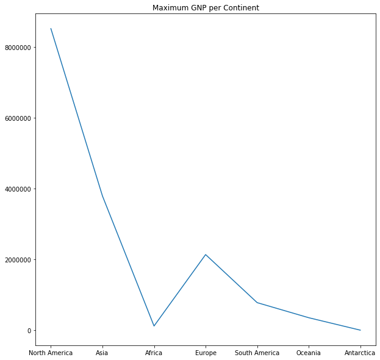

```python
import mysql.connector
import matplotlib.pyplot as plt
import pandas as pd

mydb = mysql.connector.connect(
    host='localhost',
    user='root',
    password='abcdef',
    database='world'
)

mycursor = mydb.cursor()
mycursor.execute("SELECT MAX(GNP) as MaximumGNP, continent FROM country GROUP BY continent")
myresult = mycursor.fetchall()
df = pd.DataFrame(myresult,columns=mycursor.column_names)

plt.figure(figsize=(10,10))
plt.plot(df['continent'],df['MaximumGNP'])
plt.title("Maximum GNP per Continent")
plt.show()
```

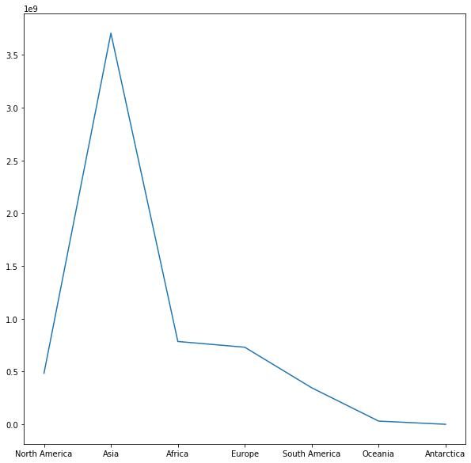

```python
import mysql.connector
import matplotlib.pyplot as plt
import pandas as pd

mydb = mysql.connector.connect(
    host='localhost',
    user='root',
    password='abcdef',
    database='world'
)

mycursor = mydb.cursor()
mycursor.execute("SELECT SUM(population) as TotalPopulation, continent FROM country GROUP BY continent")
myresult = mycursor.fetchall()
df = pd.DataFrame(myresult,columns=mycursor.column_names)

plt.figure(figsize=(10,10))
plt.plot(df['continent'],df['TotalPopulation'])
plt.show()
```

### Bars

Merupakan salah satu jenis grafik yang berbentuk bar atau batang

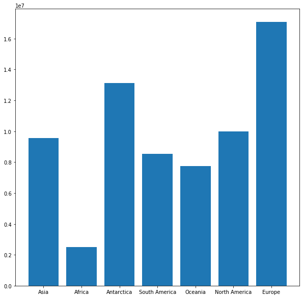

```python
import mysql.connector
import matplotlib.pyplot as plt
import pandas as pd

mydb = mysql.connector.connect(
    host='localhost',
    user='root',
    password='abcdef',
    database='world'
)

mycursor = mydb.cursor()
mycursor.execute("SELECT continent, surfacearea FROM country WHERE surfacearea > (SELECT AVG(surfacearea) FROM COUNTRY) ORDER BY Name")
myresult = mycursor.fetchall()
df = pd.DataFrame(myresult,columns=mycursor.column_names)

plt.figure(figsize=(10,10))
plt.bar(df['continent'],df['surfacearea'])
plt.show()
```

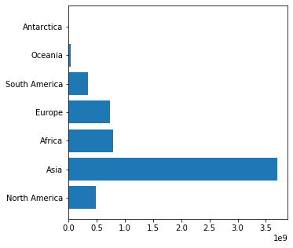

```python
import mysql.connector
import matplotlib.pyplot as plt
import pandas as pd

mydb = mysql.connector.connect(
    host='localhost',
    user='root',
    password='abcdef',
    database='world'
)

mycursor = mydb.cursor()
mycursor.execute("SELECT SUM(population) as TotalPopulation, continent FROM country GROUP BY continent")
myresult = mycursor.fetchall()
df = pd.DataFrame(myresult,columns=mycursor.column_names)

plt.figure(figsize=(5,5))
plt.barh(df['continent'],df['TotalPopulation'])
plt.show()
```

### Scatter

Merupakan function yang memberikan sebuah dot atau titik pada setiap nilai yang ada. Function ini membutuhkan dua buah array yang memiliki panjang yang sama, satu array untuk menunjukkan titik x dan satu lagi menunjukkan titik y

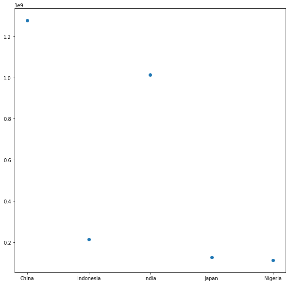

```python
import mysql.connector
import matplotlib.pyplot as plt
import pandas as pd

mydb = mysql.connector.connect(
    host='localhost',
    user='root',
    password='abcdef',
    database='world'
)

mycursor = mydb.cursor()
mycursor.execute("SELECT AVG(population) AS RataRata, name FROM country WHERE CODE LIKE '%N%' GROUP BY name HAVING RataRata > 100000000")
myresult = mycursor.fetchall()
df = pd.DataFrame(myresult,columns=mycursor.column_names)

plt.figure(figsize=(10,10))
plt.scatter(df['name'],df['RataRata'])
plt.show()
```

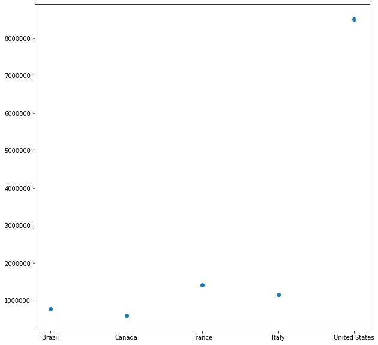

```python
import mysql.connector
import matplotlib.pyplot as plt
import pandas as pd

mydb = mysql.connector.connect(
    host='localhost',
    user='root',
    password='abcdef',
    database='world'
)

mycursor = mydb.cursor()
mycursor.execute("SELECT SUM(GNP) AS TotalGNP, name FROM country WHERE CODE LIKE '%A%' GROUP BY name HAVING TotalGNP > 500000")
myresult = mycursor.fetchall()
df = pd.DataFrame(myresult,columns=mycursor.column_names)

plt.figure(figsize=(10,10))
plt.scatter(df['name'],df['TotalGNP'])
plt.show()
```